# Principios de Gráficos Analíticos

Autor/a

Afiliación

Roger D. Peng, Associate Professor of Biostatistics

Universidad Central de Venezuela- Escuela de Economía. 2025-1

## Nota

Esta presentación es una traducción de “*Principles of Analytic Graphics*” de Roger D. Peng, quien es “*Associate Professor of Biostatistics*” en la “Johns Hopkins Bloomberg School of Public Health” y se encuentra contenida en el curso “*Exploratory Data Analysis*” de la especialización en “*Data Science*” impartida en la plataforma educacional *Coursera*.  
Los textos han sido traducidos sin consentimiento del autor ni revisión del mismo.

Los gráficos que se muestran no son los incluidos en la presentación original.

## Principios de Gráficos Analíticos -1

- Principio 1: Mostrar comparaciones
  - La evidencia para una hipótesis es siempre *relativa* a otra hipótesis compitiendo.
  - Siempre pregunta “¿En comparación con qué?”

## Mostrar Comparaciones -1

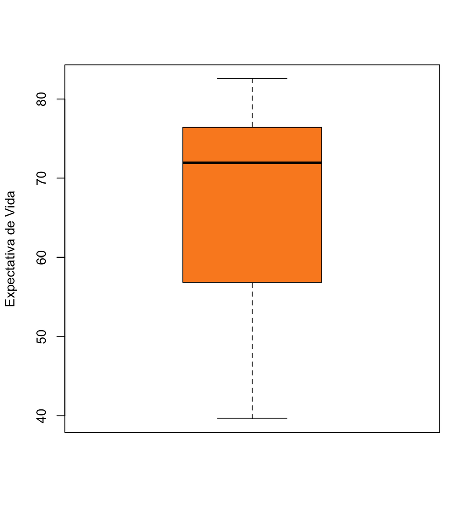

## Mostrar Comparaciones -2

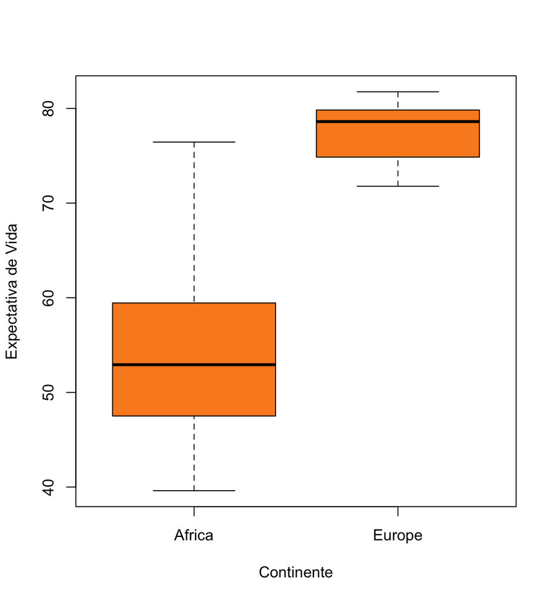

## Mostrar Comparaciones -3

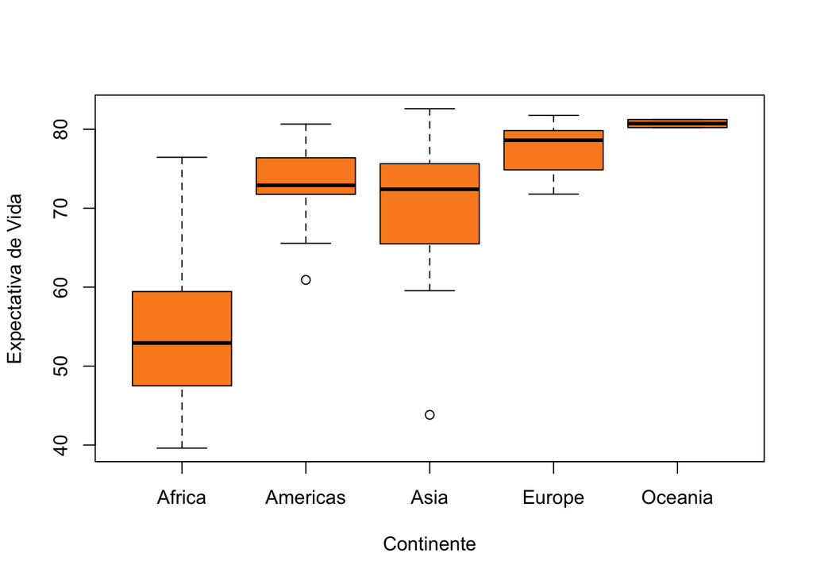

## Mostrar Comparaciones -4

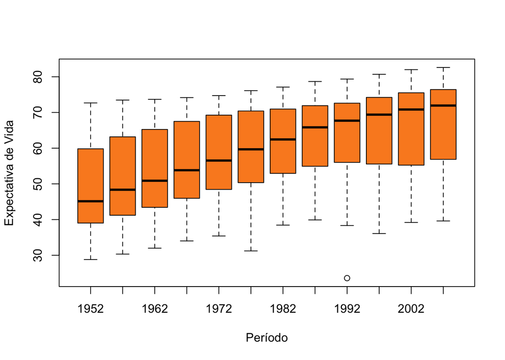

## Principios de Gráficos Analíticos -2

- Principio 2: Mostrar causalidad, mecanismos, explicaciones, estructura sistemática:
  - Cuál es el marco conceptual-teórico para sustentar la causalidad que quieres analizar

## Estimación Impacto

[figure not shown]

## Estimación Impacto 2

[figure not shown]

Tomado de La Evaluación de Impacto en la Práctica, Banco Mundial [enlace](https://openknowledge.worldbank.org/server/api/core/bitstreams/6f2eebf7-1a3c-5f67-a9c3-c39f68299ed9/content)

## Principios de Gráficos Analíticos -3

- Principio 3: Mostrar datos multivariable:
  - multivariable => más de dos variables
  - El mundo real es multivariable
  - Hay que escapar de la “tierra plana”

## Multivariable 1:

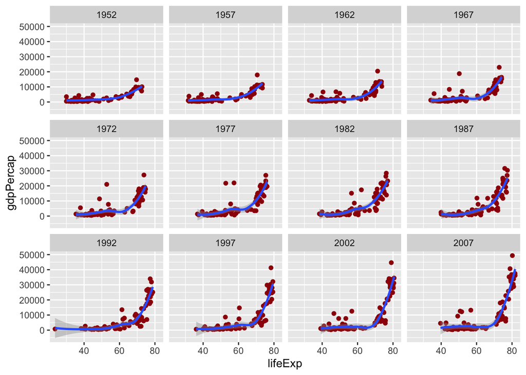

## Multivariable 2:

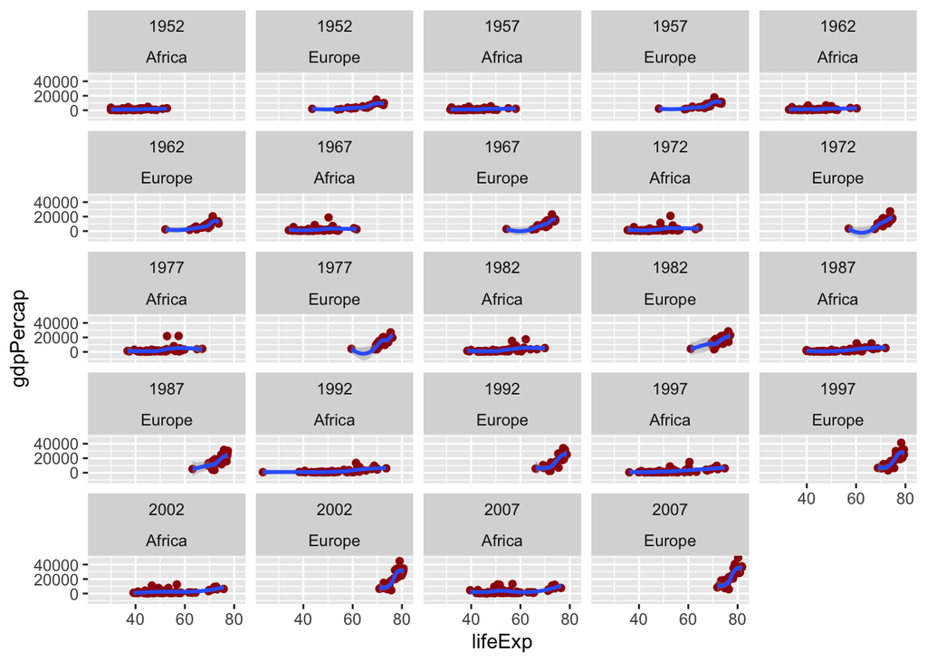

## Principios de Gráficos Analíticos -4

- Principio 4: Integrar múltiples modos de evidencia
  - Integre completamente palabras, números, imágenes, diagramas
  - Los gráficos de datos deben hacer uso de muchos modos de presentación de datos
  - No permita que la herramienta dirija el análisisx

## Integrar Distintas Formas de Evidencia

[figure not shown]

## Principios de Gráficos Analíticos -5

- Principio 5: Describa y documente la evidencia con etiquetas, escalas, fuentes, etc., apropiadas.
  - Un gráfico de datos debe contar una historia completa y creíble.

## Principios de Gráficos Analíticos -6

- Principio 6: El contenido es rey
  - Las presentaciones analíticas finalmente prosperan o fracasan dependiendo de la calidad, relevancia e integridad de su contenido.

## Resumen

- Principio 1: Mostrar comparaciones
- Principio 2: Mostrar causalidad, mecanismo, explicación
- Principio 3: Mostrar datos multivariables
- Principio 4: Integrar múltiples modos de evidencia
- Principio 5: Describir y documentar la evidencia
- Principio 6: El contenido es rey

## Referencias

Edward Tufte (2006). *Beautiful Evidence*, Graphics Press LLC. www.edwardtufte.com